# Practical Time Series Analysis Week 2

Instructor: Thistleton & Sadigov, State University of New York

Here are learn to use the package called **astsa**: **Applied Statistical Time Series Analysis** This library contains certain data sets like **jj**: **Johnson and Johnsons quaterly earnings per share** containing 84 quarters (21 years) measured from the first quarter of 1960 to the last quarter of 1980.

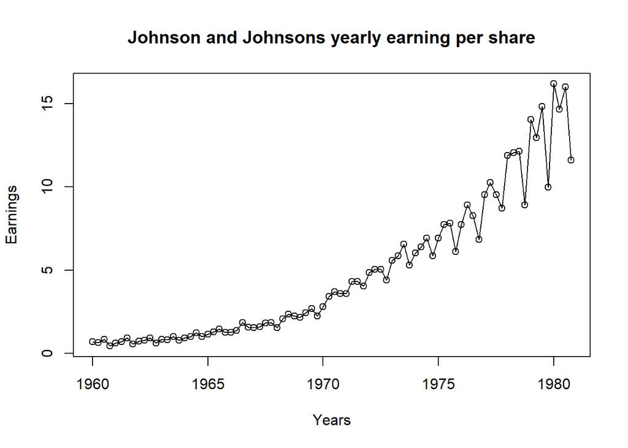

```r
library(astsa)
plot(jj, type= "o", main="Johnson and Johnsons yearly earning per share",
     xlab="Years", ylab="Earnings")
```

There are more data sets available in this “astsa” package.

### Auto Correlation cofficient (acf())

If X and Y are two random variables, the covariance (linear dependency between the variables) is given by $cov(X,Y)=E[(X-\mu_X)(Y-\mu_Y)]$ . Now the autocovariance coefficients at different lags is given by $\gamma_k=cov(x_{t+k}, x_t)$ which is estimated by $c_k$, assuming weak stationarity.  
The estimation is given by the formula $c_k=\frac{\sum_{t=1}^{N-k}(x_t-\bar x)(x_{t+k}-\bar x)}{N}$ and $\bar x=\frac{\sum_{t=1}^N x_t}{N}$.

We will try to simulate a purely random process, i.e. a time series with no specific pattern. This we will generate using rnorm.

```r
purely_rand_pro= ts(rnorm(100))
print(purely_rand_pro)
```

```
## Time Series:
## Start = 1
## End = 100
## Frequency = 1
##   [1] -1.639818057 -1.190972957  0.079792371 -0.003079325 -0.026897120
##   [6] -0.507317699 -1.304766186  0.784607896 -0.850467551  0.815748097
##  [11] -1.302184101  1.059355053 -0.129307341  0.035403530 -0.622026942
##  [16] -0.683933911  1.131817280  0.462109004 -0.650470510  0.818837141
##  [21]  1.644205038 -0.269010276  0.160725058  0.586233306 -0.002358500
##  [26] -0.699826732  2.507186777 -0.483226640 -0.174684915  0.329504293
##  [31] -0.794038797  0.979623678  0.296431926 -1.993567004  1.116510178
##  [36] -0.653315140 -2.352680162  0.685738791 -0.302663159  1.074552949
##  [41] -0.595409079 -0.476014691 -0.288110981  0.315224062 -2.092578824
##  [46]  1.150665185 -0.188428518 -0.388261156 -0.119592245  0.128914492
##  [51]  1.114792453  1.341465206 -1.041669278 -0.846842791 -1.014554063
##  [56]  0.502321032  0.377518552 -0.754507888  0.567245319 -0.368663369
##  [61]  0.647700817  1.162216101 -0.972020994 -0.274444011  0.344339577
##  [66]  1.975262059 -0.971106984 -3.114156661 -1.061849971  0.872393336
##  [71] -0.097184229  0.489315123 -0.470565929  0.469927138  0.990067721
##  [76]  0.598323896 -0.259989830 -0.479425432 -1.437769800  1.066359431
##  [81]  1.682830730  0.270801237 -0.568536442 -0.863403702  2.058528194
##  [86]  1.579842035  0.203116782  0.971163764  0.418729509  1.105737276
##  [91] -0.577587684 -0.202522026  0.178132988 -0.505838209 -0.645352912
##  [96] -0.284397819  1.330643294 -0.628496882 -0.385538593  0.836362290
```

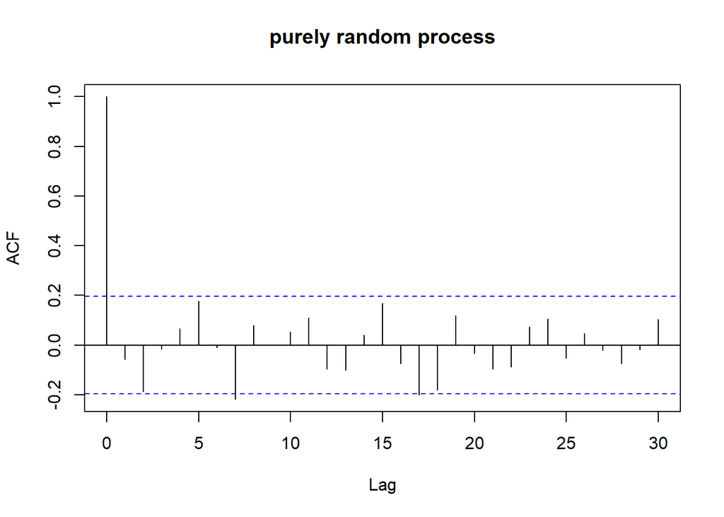

```r
prp_acf=acf(purely_rand_pro, type= 'correlation', main="purely random process", lag.max = 30)
```

```r
prp_acf$acf
```

```
## , , 1
##
##               [,1]
##  [1,]  1.000000000
##  [2,] -0.056898159
##  [3,] -0.186957397
##  [4,] -0.016200295
##  [5,]  0.065885350
##  [6,]  0.177866277
##  [7,] -0.009382426
##  [8,] -0.217936945
##  [9,]  0.078410081
## [10,]  0.002356068
## [11,]  0.052416366
## [12,]  0.110282769
```

[output cut: 19 more lines]

### Random walk

The model is $X_t=X_{t-1}+Z_t$ where $Z_t=Normal(\mu, \sigma^2)$. $Z_t$ is the noice at each time t. So basically, $x_0=z_0, \ x_1=x_0+z_1=z_0+z_1$ and so on. Thus we obtain $x_t=\sum_{k=0}^t z_k$, which gives the exp($X_t$)=$\mu t$ and Var($x_t$)=$\sigma^2 t$

Lets just create a random walk:

```r
x=NULL
x[1]=0
for (i in 2:1000)
  {
  x[i]=x[i-1]+rnorm(1)
}
head(x)
```

```
## [1] 0.0000000 0.7388190 1.4269514 1.8194144 0.9980052 3.0397338
```

```r
length(x)
```

```
## [1] 1000
```

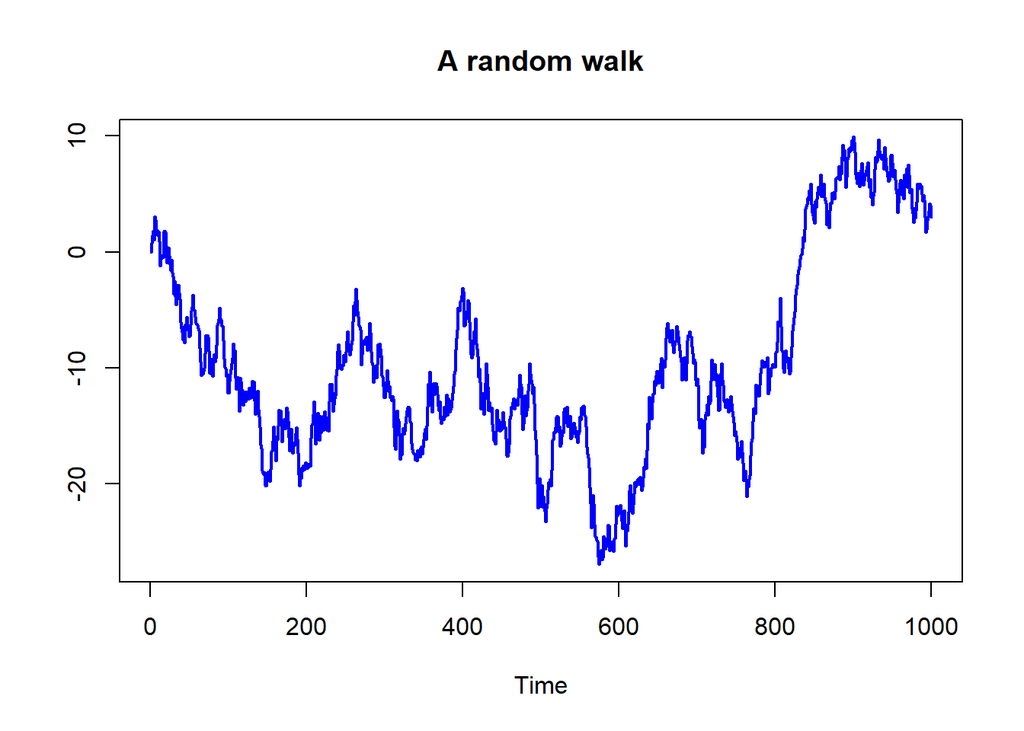

```r
random_walk=ts(x)
plot(random_walk, main="A random walk", lwd=2,col="blue", ylab="")
```

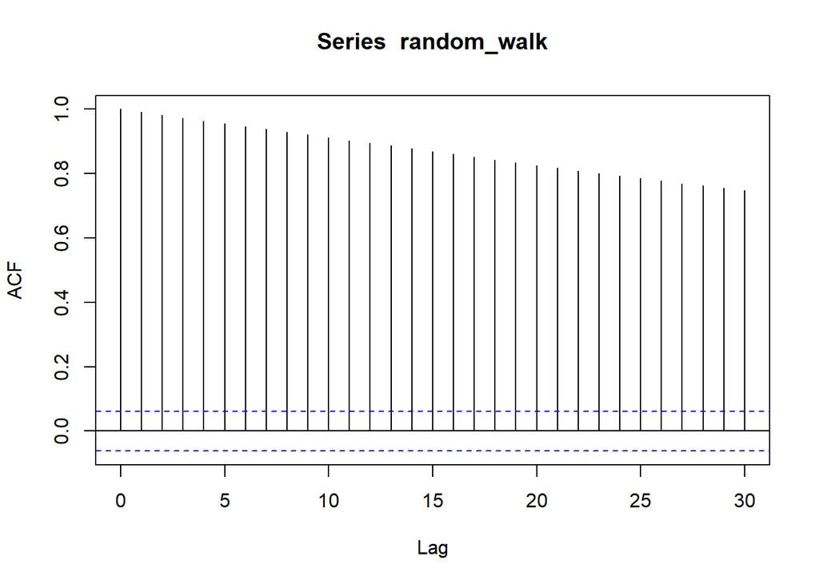

```r
acf(random_walk)
```

Now as the data was not stationary so this is showing a high correlation, so we shall first try to remove the non stationary factors from the data.

This shows some kind of trend, which can be removed by diff() function.

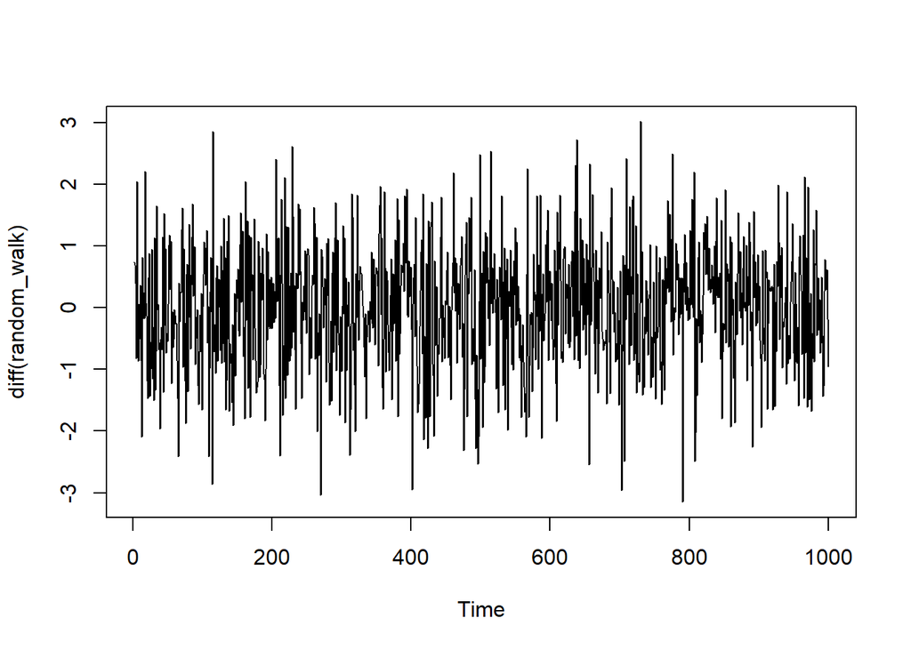

```r
plot(diff(random_walk))
```

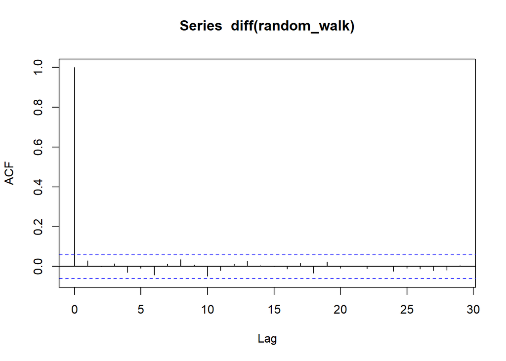

```r
acf(diff(random_walk))
```

We see that the trend is removed and a purely random precess acf is obtained.

### Moving Average Model.

**Model**:**$X_t=Z_t+0.7Z_{t-1}+0.2Z_{t-2}$** considering $Z_t$’s are normally distributed. Also $Z_i$ are iid. Here according to the instructor we will be designing a moving average with lag two.

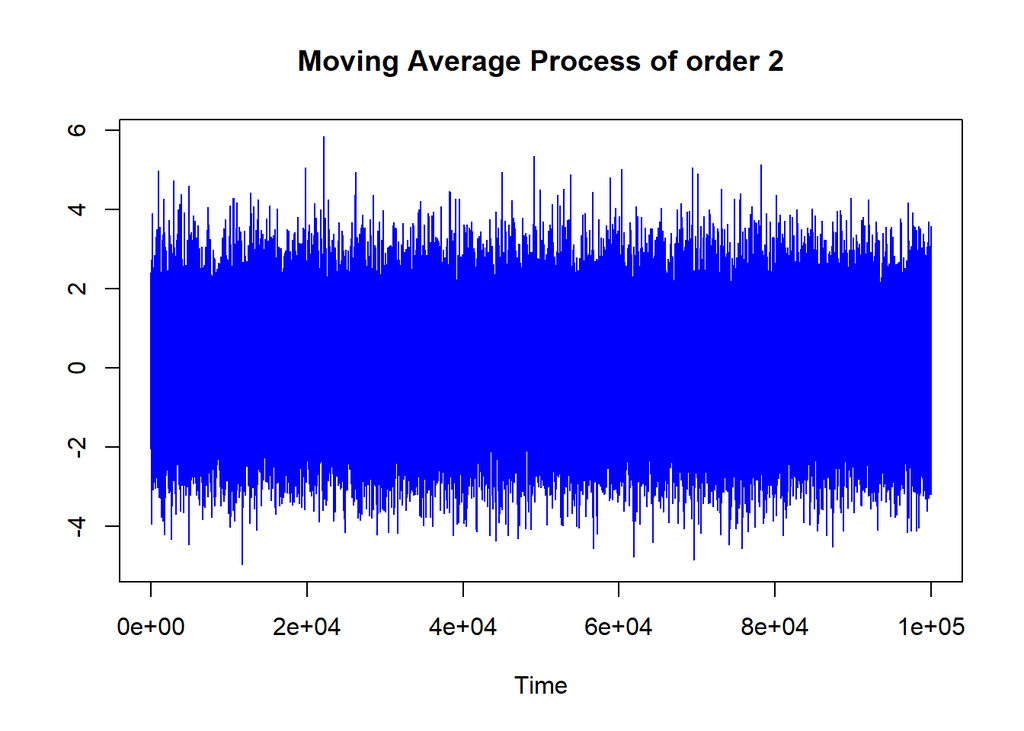

```r
# generate noise
noise= rnorm(100000)

# moving average with lag two variable
ma_l2= NULL

# defining the model with the specified lag
for (i in 3:100000) {
  ma_l2[i]= noise[i]+ 0.7*noise[i-1]+ 0.2*noise[i-2]
}

# shifting data to left by two units
moving_avg_proc= ma_l2[3:100000]

# Putting time series structure on the data
moving_avg_proc=ts(moving_avg_proc)

# Partition output graphics on a multiframe of two rows and one column
# par(mfrow=c(2,1))

# Plotting the process
plot(moving_avg_proc, main="Moving Average Process of order 2", ylab=' ', col="blue")
```

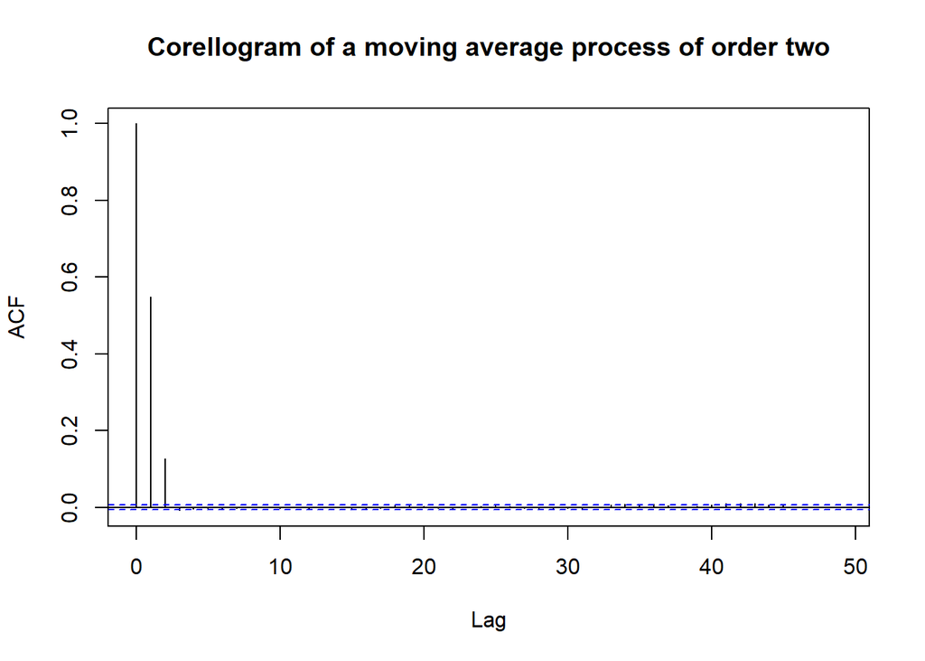

```r
# Plotting the acf

acf(moving_avg_proc, main="Corellogram of a moving average process of order two")
```

Since this is a moving average process fo order two, we see that till lag two, there is a coorelation, beyond that the process have become random.

Which tells us that the ACF of a MA process of lag k, cuts of after lag k.